# Análise de Gastos de Deputados: Nossas Perguntas

Luiz Fernando da Silva

27 de agosto de 2018

## Descrição dos dados que serão utilizados nas análises

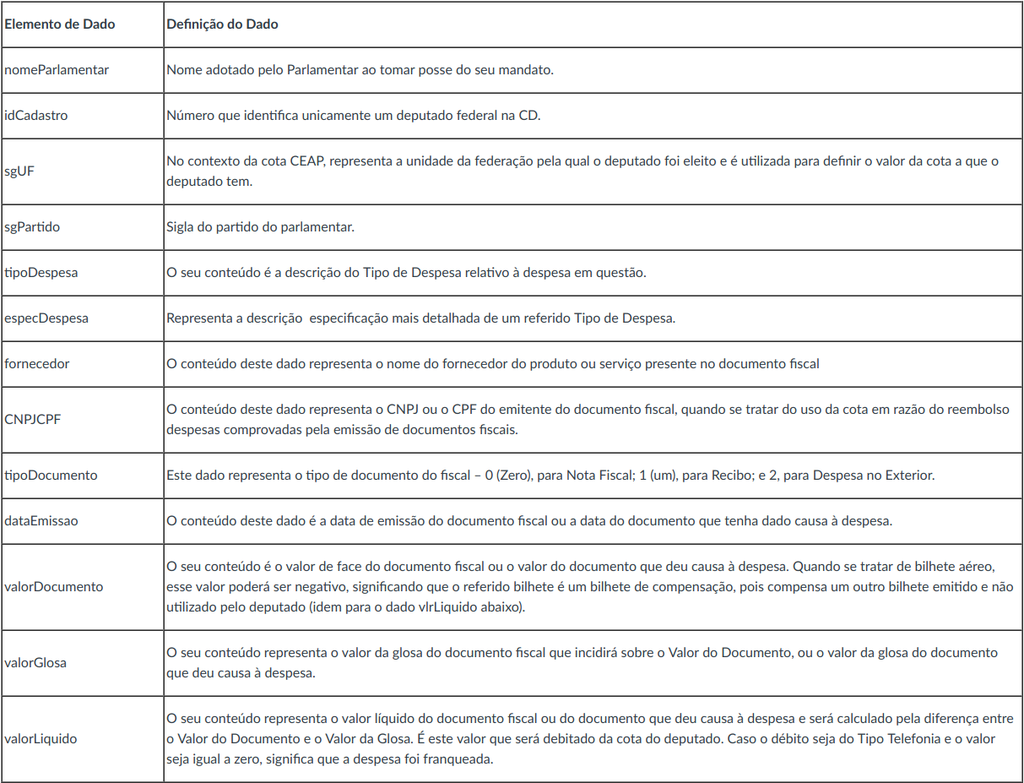

# Questão 1

### Quais são os deputados que gastaram mais dinheiro da CEAP? Quais são os mais econômicos?

Como mostrado nos gráficos abaixo os deputados que mais gastaram foram Edio Lopes, Rocha Abel Mesquita Jr., Alan Rick e Jhonatan de Jesus, e o que menos gastaram foram Renam filho, Marcelo Almeida, Marcio Monteiro, Eliseu Padilha e Camilo Cola. Por meio deste gráfico pode-se perceber a grande diferença na quantidade de gastos entre os deputados que mais gastaram e os que menos gastaram. Com essa análise existe uma questão a ser pensada: Qual motivo levou a essa diferença tão grande entre os gastos dos deputados?

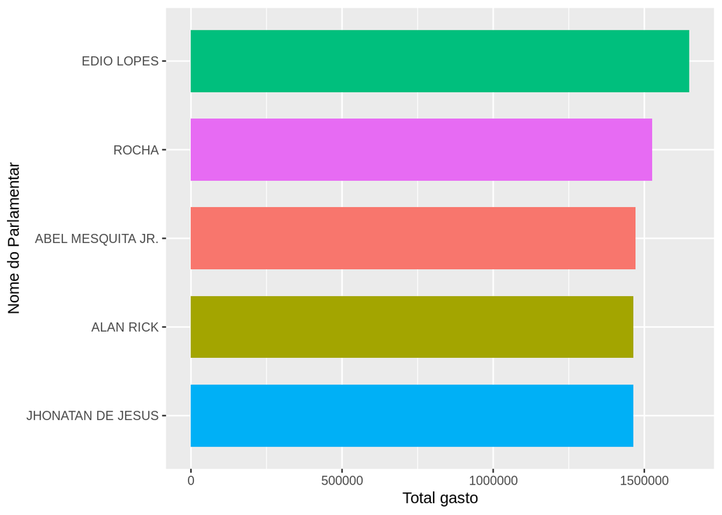

```r
# Este código recupera os 5 deputados que mais gastaram
maisGastadores <- data %>%
  group_by(nomeParlamentar) %>%
  summarise(total = sum(valorLíquido)) %>%
  arrange(-total) %>%
  slice(1:5)

# Este código recupera os 5 deputados que menos gastaram
menosGastadores <- data %>%
  group_by(nomeParlamentar) %>%
  summarise(total = sum(valorLíquido)) %>%
  arrange(total) %>%
  slice(1:5)

# Plotando gráfico de barras dos deputados que mais gastaram
maisGastadores %>%
  ggplot(aes(x=reorder(nomeParlamentar, total), y=total, fill=nomeParlamentar)) +
  geom_col(width = 0.7, show.legend = FALSE) +
  coord_flip() + labs(x="Nome do Parlamentar", y="Total gasto")
```

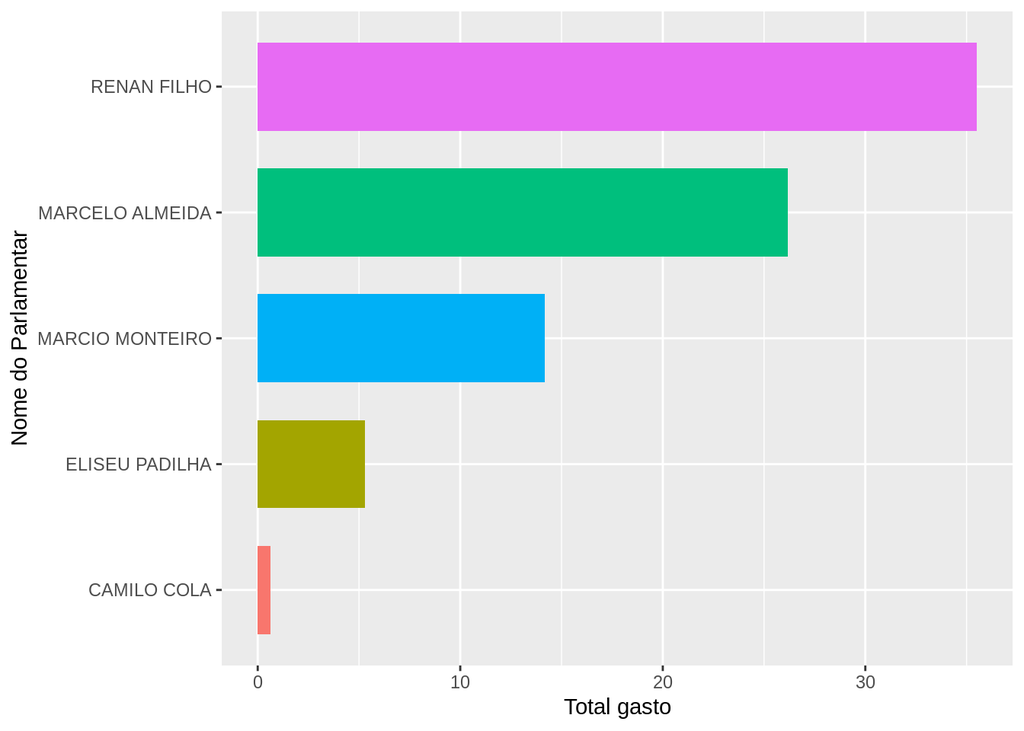

```r
# Plotando gráfico de barras dos deputados que mais gastaram
menosGastadores %>%
  ggplot(aes(x=reorder(nomeParlamentar, total), y=total, fill=nomeParlamentar)) +
  geom_col(width = 0.7, show.legend = FALSE) +
  coord_flip() + labs(x="Nome do Parlamentar", y="Total gasto")
```

# Questão 2

### Quais os estados cujos deputados gastam mais no exterior? Quais os estados cujos deputados gastam menos no exterior?

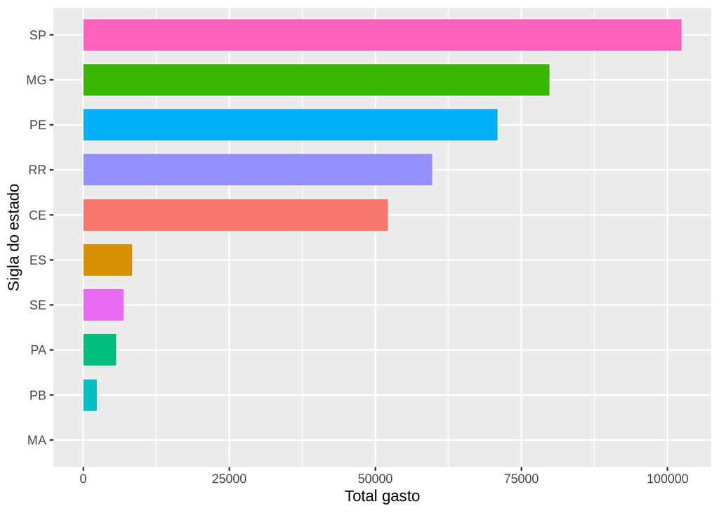

```r
# Este código pega os 5 estados cujos deputados mais gastam no exterior
maiorGastoExterior <- data %>%
  group_by(sgUF) %>%
  filter(tipoDocumento == 2) %>%
  summarise(total = sum(valorLíquido)) %>%
  arrange(-total) %>%
  slice(1:5)

# Este código pega os 5 estados cujos deputados menos gastam no exterior
menorGastoExterior <- data %>%
  group_by(sgUF) %>%
  filter(tipoDocumento == 2) %>%
  summarise(total = sum(valorLíquido)) %>%
  arrange(total) %>%
  slice(1:5)

# Unindo os dados referentes ao maiorGastoExterior e o menorGastoExterior
gastosExterior <- union(maiorGastoExterior, menorGastoExterior)

#Plotando gráfico de barras para exibir as informações sobre os gastos
gastosExterior %>%
  ggplot(aes(x=reorder(sgUF, total), y=total, fill=sgUF)) +
  geom_col(width = 0.7, show.legend = FALSE) +
  coord_flip() + labs(x="Sigla do estado", y="Total gasto")
```

# Questão 3

### Quais os partidos cujos parlamentares mais usam CEAP no estado da Paraíba? Quais são os que menos usam? Mesmas perguntas considerando valores em R$.

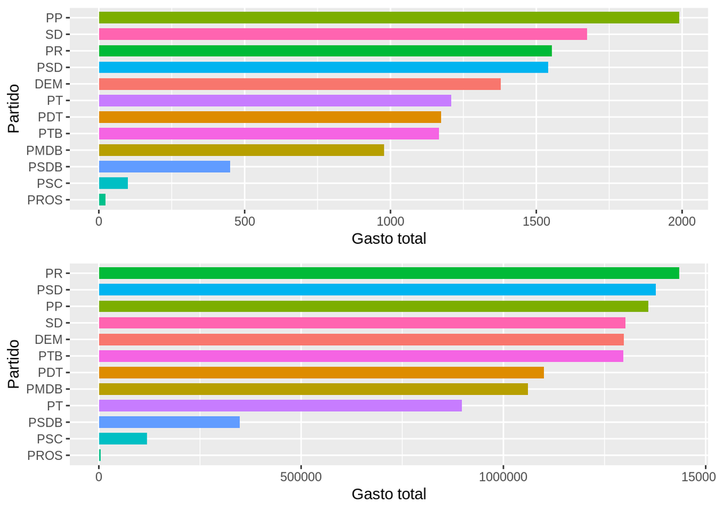

```r
# Sumarizando os dados de modo a agrupar por partidos no estado da paraíba
# A quantidade de vezes que um determinado partido usou o CEAP é calculada com base na mediana
# Já que a mesma é uma medida que não é afetada do valores extermos
gastosPartidosPB <- data %>%
  filter(sgUF == "PB") %>%
  group_by(nomeParlamentar, idCadastro) %>%
  summarise(totalParlamentar = sum(valorLíquido), sgPartido=first(sgPartido), count = n()) %>%
  group_by(sgPartido) %>%
  summarise(total = median(totalParlamentar), count = median(count)) %>%
  arrange(total)

# Plotando o gráfico de barras que mostra o ranking dos partidos que mais usam CEAP
grafico1 <- gastosPartidosPB %>%
  arrange(count) %>%
  ggplot(aes(x=reorder(sgPartido, count), y=count, fill=sgPartido)) +
  geom_col(width = 0.7, show.legend = FALSE) +
  coord_flip() + labs(x="Partido", y="Gasto total")

# Plotando o gráfico de barras que mostra o ranking dos partidos que mais gastaram
grafico2 <- gastosPartidosPB %>%
  ggplot(aes(x=reorder(sgPartido, total), y=total, fill=sgPartido)) +
  geom_col(width = 0.7, show.legend = FALSE) +
  coord_flip() + labs(x="Partido", y="Gasto total")

grid.arrange(grafico1, grafico2, nrow = 2)
```

#### Agrupando dados dos dados por nome dos parlamentares meses e anos e filtrando pelos que ultrapassaram o limite mensal de seu estado.

```r
# Filtrando os dados para considerar apenas os deputados que passaram do limite mensal de seu estado
dadosFiltrados <- data %>%
  mutate(ano = format(dataEmissao, "%y"), mes = format(dataEmissao, "%m")) %>%
  group_by(nomeParlamentar, ano, mes, idCadastro) %>%
  summarise(total = sum(valorLíquido), limite_mensal = first(limite_mensal)) %>%
  filter(limite_mensal < total)

# Agrupando os dados pelo nome id dos deputados
# O valor utilizado para mostrar o quanto um determinado deputado passou do limite da cota é baseado na mediana
# Já que a mesma é uma medida que não é afetada do valores extermos
dadosAgrupadosPorParlamentar <- dadosFiltrados %>%
  mutate(extra = total - limite_mensal) %>%
  group_by(nomeParlamentar, idCadastro) %>%
  summarise(extra = median(extra), vezesExtrapoladas = n()) %>%
  ungroup()
```

# Questão 4

### Quais os deputados que mais ultrapassam o limite de CEAP do seu estado?

Os dois gráficos abaixo mostram respectivamente o top 10 dos deputados que ultrapassaram mais vezes o limite mensal de da cota do CEAP e o top 10 da mediana valor total do limite ultrapassado de cada mês. O primeiro gráfico mostra que os 10 deputados do ranking passaram muitas vezes do limite da cota, o que pode ter causado uma grande quantidade de gastos extras usando o dinheiro público. No segundo gráfico é possível perceber que os deputados exibidos ultrapassaram muito o valor de sua cota, algo em torno de 50 mil e 160 mil. Ao comparar os dois gráficos pode-se visualizar que nenhum dos deputados que ultrapassaram o limite mais vezes está no ranking do que mais gastaram, isso pode ser explicado pelo fato de que alguns deputados extrapolaram muito o limite mensal do seu estado. Analizado os dois gráficos é possível questionar-se sobre qual a despesa que teve maior impácto para que esses deputados ultrapassarem tanto o limite e se esses gastos extras são realmente necessários.

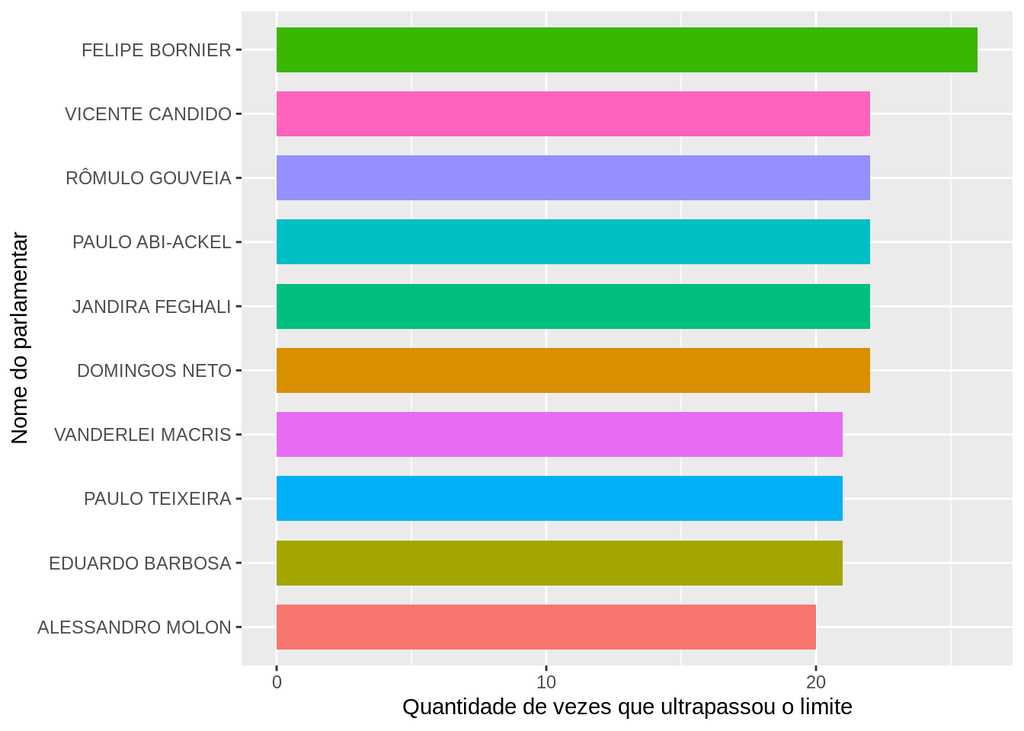

```r
# Gerando gráfico de barras exibindo os gastos dos 10 parlamentares que ultrapassaram o limite mais vezes
dadosAgrupadosPorParlamentar %>%
  arrange(-vezesExtrapoladas) %>%
  slice(1:10) %>%
  ggplot(aes(x=reorder(nomeParlamentar, vezesExtrapoladas), y=vezesExtrapoladas, fill=nomeParlamentar)) +
  geom_col(width = 0.7, show.legend = FALSE) +
  coord_flip() +
  labs(x="Nome do parlamentar", y="Quantidade de vezes que ultrapassou o limite")
```

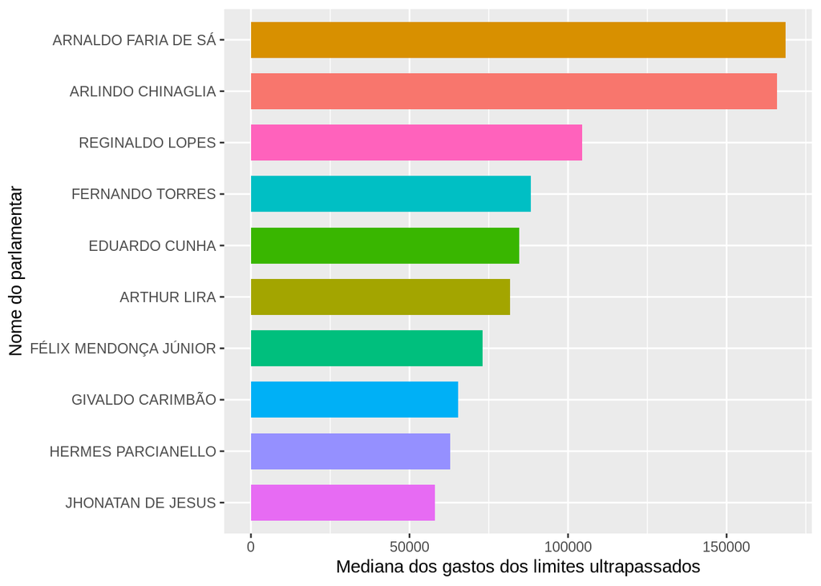

```r
# Gerando gráfico de barras exibindo os gastos dos 10 parlamentares que mais ultrapassaram o limite
dadosAgrupadosPorParlamentar %>%
  arrange(-extra) %>%
  slice(1:10) %>%
  ggplot(aes(x=reorder(nomeParlamentar, extra), y=extra, fill=nomeParlamentar)) +
  geom_col(width = 0.7, show.legend = FALSE) +
  coord_flip() +
  labs(x="Nome do parlamentar", y="Mediana dos gastos dos limites ultrapassados")
```

# Questão 5

### Quais estados cujos parlamentares gastam mais com passagens aéreas?

O gráfico abaixo mosrta que São Paulo e o Amazonas são os estados cujos parlamentares mais gastam com passagens aéreas. Pode-se perceber também que há uma diferença muito grande entre esses estados e os que menos gastam como Distrito Federal e amapá, isso pode ser explicado em partes pelo número de deputados de cada estado e a quantidade de viagens para o exterior que tendem a ser mais caras.

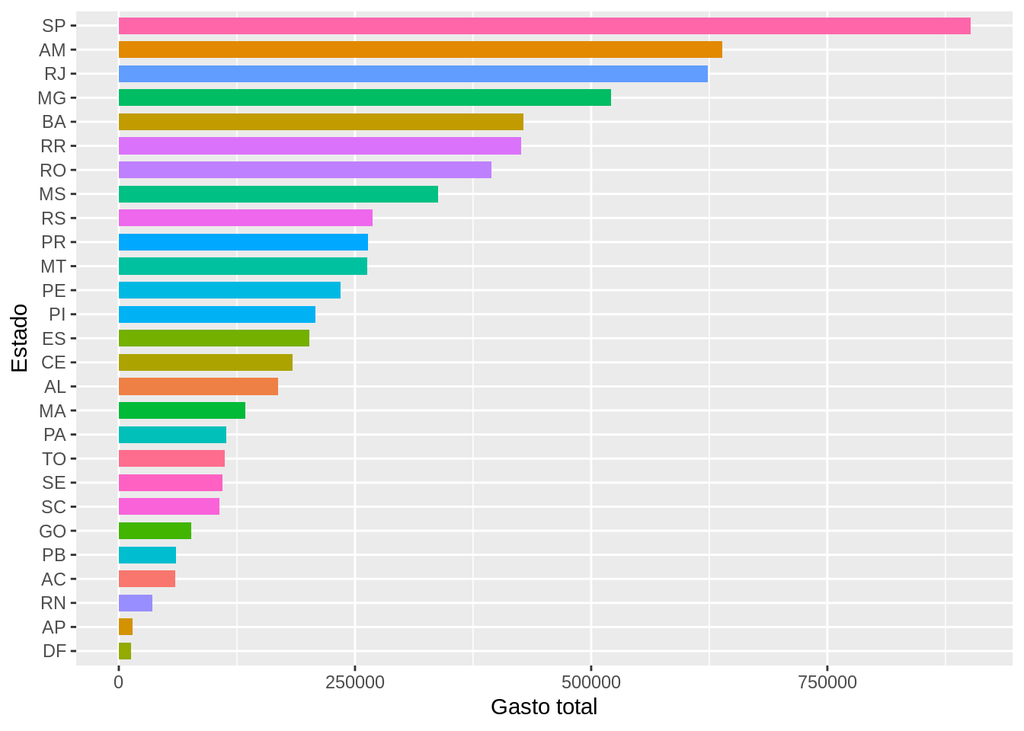

```r
# Filtrando os dados para recuperar apenas as despesas com passagens aéreas
maiorGastos <- data %>%
  filter(tipoDespesa == "PASSAGENS AÉREAS") %>%
  group_by(sgUF) %>%
  summarise(total = sum(valorLíquido)) %>% na.omit()

# Plotando o gráfico que mostra o ranking dos estado que mais gastam com passagens aéreas
maiorGastos %>%
  ggplot(aes(x=reorder(sgUF, total), y=total, fill=sgUF)) +
  geom_col(width = 0.7, show.legend = FALSE) +
  coord_flip() + labs(x="Estado", y="Gasto total")
```

# Questão 6

### Escolha três partidos e responda: Quais são os tipos de despesa mais utilizados no uso da CEAP pelos deputados desses partidos? Mesma pergunta considerando valores em R$.

Os partidos escolhidos foram PT, PMDB e PSDB, e os gráficos abaixo correspondem respectivamente a quantidades de vezes que esses partidos tiveram uma determinada despesa e o quanto foi gasto com cada despesa. Olhando o primeiro gráfico pode-se observar que o tipo de despesa mais frequente entre esses partidos é a emissão de bilhetes aéreos, o que mostra que os deputados viajam muito de avião, ela é também a maior despesa em relação a quantidade de gastos no segundo gráfico. Comparando os dois gráfico é possível perceber que nem todas os tipos de despesas mais frequentemente utilizadas são as que mais geram custos, como por exemplo a despesa com combustíveis e lubrificantes é a segunda mais frequênte, porém ao olhar para o segundo gráfico ela aparecem em quinto lugar, e a despesa que aparece em segundo é a divulgação das atividades parlamentares o que mostra que para esses partidos a divulgação de suas atividades é uma atividade de grande importância o que pode explicar o grande investimento nessa atividade.

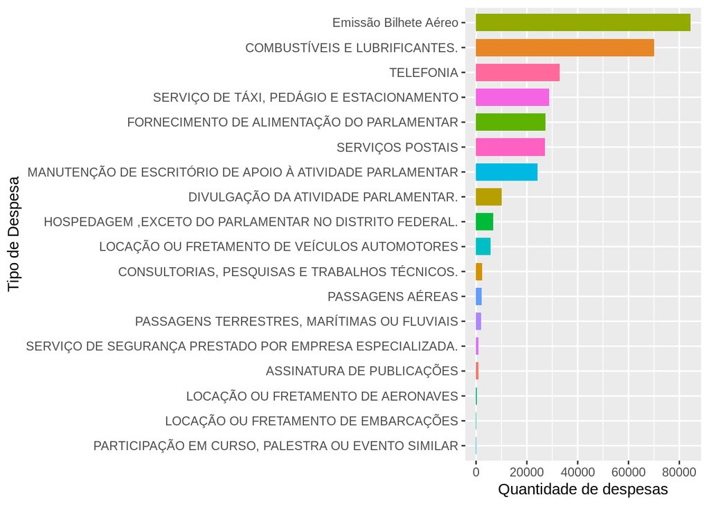

```r
# Filtrando partidos
partidos <- data %>% filter(sgPartido %in% c("PT", "PMDB", "PSDB"))

# Agrupando dados filtrados por tipo de despesa
gastos <- partidos %>% group_by(tipoDespesa) %>%
  summarise(total = sum(valorLíquido), count = n()) %>%
  arrange(-total)

# Plotando gráfico que mostra o ranking das despesas mais utilizadas
gastos %>%
  arrange(-count) %>%
  ggplot(aes(x=reorder(tipoDespesa, count), y=count, fill=tipoDespesa)) +
  geom_col(width = 0.7, show.legend = FALSE) +
  coord_flip() + labs(x="Tipo de Despesa", y="Quantidade de despesas")
```

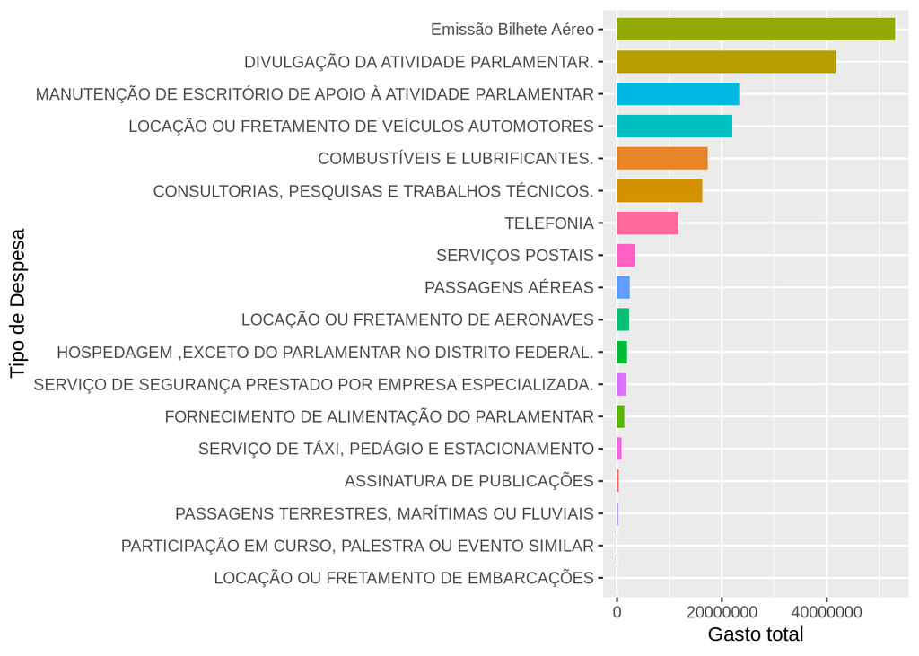

```r
# Plotando gráfico que mostra o ranking das despesas que mais geraram custos
gastos %>%
  ggplot(aes(x=reorder(tipoDespesa, total), y=total, fill=tipoDespesa)) +
  geom_col(width = 0.7, show.legend = FALSE) +
  coord_flip() + labs(x="Tipo de Despesa", y="Gasto total")
```